```python
import pandas as pd
import numpy as np
from sklearn.model_selection import train_test_split # Import train_test_split function
from sklearn.ensemble import RandomForestClassifier,RandomForestRegressor,AdaBoostClassifier
from sklearn.neighbors import KNeighborsClassifier
from sklearn.model_selection import GridSearchCV
from scipy.spatial.distance import cdist
from sklearn.cluster import KMeans
import seaborn as sns
from sklearn.metrics import confusion_matrix
import matplotlib.pyplot as plt
from sklearn.metrics import accuracy_score
from sklearn import preprocessing
import math
import itertools
```

# **Table of content :**

- **1 . Reading Data**
- **2 . Data Engineering and visualization**
- **3 . Prediction Models**
  - **Random Forest**
  - **KNN**

# **Helper Methods**

```python
def missing_value_of_data(data):
    total=data.isnull().sum().sort_values(ascending=False)
    percentage=round(total/data.shape[0]*100,2)
    return pd.concat([total,percentage],axis=1,keys=['Total','Percentage %'])
```

### this method extract the title from the names and replace the name feature by title

```python
def replace_names_with_titles(df):
    name_titles = []
    for name in df.Name:
        comma = name.find(",") + 1
        point = name.find(".",comma)
        name_titles.append(name[comma:point])
    df.Name = name_titles
    df.rename(columns = {'Name':'Title'}, inplace = True)
```

### filling the missing ages data with the avg. of each title

```python
def filling_age_by_titles_avg(df):
    for title in set(df.Title):
        title_age_avg = df[df.Title == title ].Age.mean()

        # in case all the ages values for this title are NaN so we have now avg for them we will use the regular age avg instead
        if math.isnan(title_age_avg) :
            title_age_avg=df.Age.mean()
        mask = df.Title == title
        df.loc[mask, 'Age'] = df.loc[mask, 'Age'].fillna(value=title_age_avg)
```

### method for deep optimizing by droping features :

#### this function tries to inhance the model's accuracy by droping the least important feature iteratively , it will stop when the accuracy start to drop or when the min number of features for the model is reached

- **curr_train_x** : train_x after droping feature at a time .
- **curr_test_x** : test_x after droping feature at a time .
- **min_features** : the function continue to drop features until reaching this number .
- **best_score** : the score of the best model .
- **isBetter** : a flag that checks if the current model after droping feature is better than the best model .
- **curr_model** : the current model that i build each time i drop a feature .
- **returns** : best_model **: the best model that was built after droping the unnecessary features .** **excluded_features** : array that include features that were excluded from the model .

```python
def optimize_by_droping_features(train_x,train_y,test_x,test_y,min_features,score,model,param_grid):

    curr_train_x =  train_x
    curr_test_x  =  test_x
    min_features =  min_features
    best_score   =  score
    isBetter     =  True
    best_model   =  model
    excluded_features = []

    while isBetter :

        if(len(curr_train_x.columns) > min_features):

            features = list(curr_train_x.columns)
            importance_df = pd.DataFrame({'feature': features,
                                          'importance': best_model.feature_importances_}).\
                                           sort_values('importance', ascending = False)

            display(importance_df)
            print()

            least_important_feature = importance_df['feature'].iloc[-1]

            print('Trying To Drop Feature : '+ least_important_feature)

            curr_train_x = train_x.drop(least_important_feature, 1)
            curr_test_x  = test_x.drop(least_important_feature, 1)

            print('Optimizing The Best Model Without The Feature , Please Wait ⏳ ... ')

            gs = GridSearchCV(best_model,param_grid = param_grid, cv = 5, n_jobs = -1,iid=False)
            gs.fit(curr_train_x,train_y)
            current_model = gs.best_estimator_
            pred_y = current_model.predict(curr_test_x)

            current_score = accuracy_score(test_y, pred_y)
            print("Accuracy After Droping Feature : ", current_score)

            if(current_score >= best_score) :

                excluded_features.append(least_important_feature)
                print('Droping Feature Was Efficient ✔️')
                print('excluded_features',excluded_features)
                print()

                train_x      = curr_train_x
                test_x       = curr_test_x
                best_score   = current_score
                best_model   = current_model
                pred_y       = best_model.predict(test_x)


            else:
                print("Droping Feature Was Not Efficient ❌")
                print()
                print("Optimization By Droping Features Is Done")
                print('excluded_features',excluded_features)
                print()
                isBetter = False
        else :
            print("Minimum Number Of Features Is Reached ⚠️")
            print("Optimization By Droping Features Is Done")
            print('excluded_features',excluded_features)
            print()
            isBetter = False
    print('The Best Score For Model is : ',best_score)
    return best_model , excluded_features
```

### viewing correlation between features in a correlation map

```python
def view_correlation(df):
    corr=df.corr()
    plt.figure(figsize=(9,9))
    sns.heatmap(corr, linewidths=0.01,square=True,annot=True,annot_kws={"size": 12},cmap='YlGnBu',linecolor="white" )
    sns.set(font_scale=0.8)
    plt.title('Correlation between features parameters matrix');
    b, t = plt.ylim()
    b += 0.5
    t -= 0.5
    plt.ylim(b, t)
    plt.show()
```

### This function prints and plots the confusion matrix.

- Normalization can be applied by setting `normalize=True`.
- Source: http://scikit-learn.org/stable/auto_examples/model_selection/plot_confusion_matrix.html

```python
def plot_confusion_matrix(cm, classes,
                          normalize=False,
                          title='Confusion matrix',
                          cmap=plt.cm.Oranges):
    if normalize:
        cm = cm.astype('float') / cm.sum(axis=1)[:, np.newaxis]
        print("Normalized confusion matrix")
    else:
        print('Confusion matrix, without normalization')

    print(cm)

    plt.figure(figsize = (10, 10))
    plt.imshow(cm, interpolation='nearest', cmap=cmap)
    plt.title(title, size = 24)
    plt.colorbar(aspect=4)
    tick_marks = np.arange(len(classes))
    plt.xticks(tick_marks, classes, rotation=45, size = 14)
    plt.yticks(tick_marks, classes, size = 14)

    fmt = '.2f' if normalize else 'd'
    thresh = cm.max() / 2.

    # Labeling the plot
    for i, j in itertools.product(range(cm.shape[0]), range(cm.shape[1])):
        plt.text(j, i, format(cm[i, j], fmt), fontsize = 20,
                 horizontalalignment="center",
                 color="white" if cm[i, j] > thresh else "black")
    b, t = plt.ylim()
    b += 0.5
    t -= 0.5
    plt.ylim(b, t)
    plt.grid(None)
    plt.tight_layout()
    plt.ylabel('True label', size = 18)
    plt.xlabel('Predicted label', size = 18)
```

```python
def elbow_met(df):
    distortions = []
    K = range(1,10)
    for k in K:
        kmeanModel = KMeans(n_clusters=k).fit(df)
        kmeanModel.fit(df)
        distortions.append(sum(np.min(cdist(df, kmeanModel.cluster_centers_, 'euclidean'), axis=1)) / df.shape[0])

    # Plot the elbow
    plt.figure(figsize=(10,7))
    plt.plot(K, distortions, 'bx-')
    plt.xlabel('k')
    plt.ylabel('Within groups sum of squares')
    plt.title('The Elbow Method showing the optimal k')
    plt.show()
```

# 1. **Reading The Data**

```python
train = pd.read_csv(r'C:\Users\L.A\Desktop\titanic\train.csv' , encoding = "ISO-8859-8")
test  = pd.read_csv(r'C:\Users\L.A\Desktop\titanic\test.csv'  , encoding = "ISO-8859-8")
passengers_id = test.PassengerId # to be used later when real life testing
```

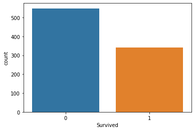

```python
sns.countplot(train.Survived)
```

# 2+3. **Data Engineering and visualization**

```python
%%HTML
<br>
<div class='tableauPlaceholder' id='viz1592437685721' style='position: relative'><noscript><a href='#'><img alt=' ' src='https:&#47;&#47;public.tableau.com&#47;static&#47;images&#47;ML&#47;ML_embarked&#47;Sheet1&#47;1_rss.png' style='border: none' /></a></noscript><object class='tableauViz'  style='display:none;'><param name='host_url' value='https%3A%2F%2Fpublic.tableau.com%2F' /> <param name='embed_code_version' value='3' /> <param name='site_root' value='' /><param name='name' value='ML_embarked&#47;Sheet1' /><param name='tabs' value='no' /><param name='toolbar' value='yes' /><param name='static_image' value='https:&#47;&#47;public.tableau.com&#47;static&#47;images&#47;ML&#47;ML_embarked&#47;Sheet1&#47;1.png' /> <param name='animate_transition' value='yes' /><param name='display_static_image' value='yes' /><param name='display_spinner' value='yes' /><param name='display_overlay' value='yes' /><param name='display_count' value='yes' /><param name='language' value='en' /><param name='filter' value='publish=yes' /></object></div>                <script type='text/javascript'>                    var divElement = document.getElementById('viz1592437685721');                    var vizElement = divElement.getElementsByTagName('object')[0];                    vizElement.style.width='100%';vizElement.style.height=(divElement.offsetWidth*0.55)+'px';                    var scriptElement = document.createElement('script');                    scriptElement.src = 'https://public.tableau.com/javascripts/api/viz_v1.js';                    vizElement.parentNode.insertBefore(scriptElement, vizElement);                </script>
<div class='tableauPlaceholder' id='viz1592437607255' style='position: relative'><noscript><a href='#'><img alt=' ' src='https:&#47;&#47;public.tableau.com&#47;static&#47;images&#47;ML&#47;ML_embarked&#47;Sheet3&#47;1_rss.png' style='border: none' /></a></noscript><object class='tableauViz'  style='display:none;'><param name='host_url' value='https%3A%2F%2Fpublic.tableau.com%2F' /> <param name='embed_code_version' value='3' /> <param name='site_root' value='' /><param name='name' value='ML_embarked&#47;Sheet3' /><param name='tabs' value='no' /><param name='toolbar' value='yes' /><param name='static_image' value='https:&#47;&#47;public.tableau.com&#47;static&#47;images&#47;ML&#47;ML_embarked&#47;Sheet3&#47;1.png' /> <param name='animate_transition' value='yes' /><param name='display_static_image' value='yes' /><param name='display_spinner' value='yes' /><param name='display_overlay' value='yes' /><param name='display_count' value='yes' /><param name='language' value='en' /><param name='filter' value='publish=yes' /></object></div>                <script type='text/javascript'>                    var divElement = document.getElementById('viz1592437607255');                    var vizElement = divElement.getElementsByTagName('object')[0];                    vizElement.style.width='100%';vizElement.style.height=(divElement.offsetWidth*0.45)+'px';                    var scriptElement = document.createElement('script');                    scriptElement.src = 'https://public.tableau.com/javascripts/api/viz_v1.js';                    vizElement.parentNode.insertBefore(scriptElement, vizElement);                </script>
<br>
```

[figure not shown]

## checking empty cells

```python
missing_value_of_data(train)
```

|  | Total | Percentage % |
| --- | --- | --- |
| Cabin | 687 | 77.10 |
| Age | 177 | 19.87 |
| Embarked | 2 | 0.22 |
| Fare | 0 | 0.00 |
| Ticket | 0 | 0.00 |
| Parch | 0 | 0.00 |
| SibSp | 0 | 0.00 |
| Sex | 0 | 0.00 |
| Name | 0 | 0.00 |
| Pclass | 0 | 0.00 |
| Survived | 0 | 0.00 |
| PassengerId | 0 | 0.00 |

### Embarked is a categorial feature , since we have only 2 missing values in Embarked , i decided to drop them instead of trying to guess their values

```python
train = train[(train.Embarked.notnull())]
```

### Cabin is a categorial feature , i decided to drop the feature since more than 50% of the values are empty

```python
#Tarin
train.drop('Cabin',1,inplace=True)

#Test
test.drop('Cabin',1,inplace=True)
```

### Ticket number and Passenger Id are unique features for each passenger so i will drop them since they will not helps us find patterns in the data

```python
#Train
train.drop('Ticket',1,inplace=True)
train.drop('PassengerId',1,inplace=True)

#Test
test.drop('Ticket',1,inplace=True)
test.drop('PassengerId',1,inplace=True)
```

### extracting name title from the name field and using it as a categorial feature for 2 reasons :

- we can use the titles to fill the missing ages according to each category avg (Mr,Mrs,Lady...) , for example a row with 'Mr' and a NaN Age will get the average of all 'Mr' rows
- having more features that will be used in the model might help our model finding patterns in the data

```python
replace_names_with_titles(train)
```

```python
replace_names_with_titles(test)
```

```python
%%html
<br>
<div class='tableauPlaceholder' id='viz1592587025547' style='position: relative'><noscript><a href='#'><img alt=' ' src='https:&#47;&#47;public.tableau.com&#47;static&#47;images&#47;Bo&#47;Book2_15925864916510&#47;Sheet1&#47;1_rss.png' style='border: none' /></a></noscript><object class='tableauViz'  style='display:none;'><param name='host_url' value='https%3A%2F%2Fpublic.tableau.com%2F' /> <param name='embed_code_version' value='3' /> <param name='site_root' value='' /><param name='name' value='Book2_15925864916510&#47;Sheet1' /><param name='tabs' value='no' /><param name='toolbar' value='yes' /><param name='static_image' value='https:&#47;&#47;public.tableau.com&#47;static&#47;images&#47;Bo&#47;Book2_15925864916510&#47;Sheet1&#47;1.png' /> <param name='animate_transition' value='yes' /><param name='display_static_image' value='yes' /><param name='display_spinner' value='yes' /><param name='display_overlay' value='yes' /><param name='display_count' value='yes' /><param name='language' value='en' /><param name='filter' value='publish=yes' /></object></div>                <script type='text/javascript'>                    var divElement = document.getElementById('viz1592587025547');                    var vizElement = divElement.getElementsByTagName('object')[0];                    vizElement.style.width='100%';vizElement.style.height=(divElement.offsetWidth*0.55)+'px';                    var scriptElement = document.createElement('script');                    scriptElement.src = 'https://public.tableau.com/javascripts/api/viz_v1.js';                    vizElement.parentNode.insertBefore(scriptElement, vizElement);                </script>
<br>
```

[figure not shown]

### filling the missing age values according to the averages

```python
filling_age_by_titles_avg(train)
```

```python
filling_age_by_titles_avg(test)
```

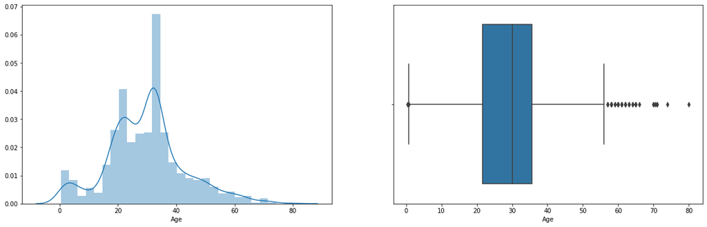

```python
f = plt.figure(figsize=(20,6))
f.add_subplot(1,2,1)
sns.distplot(train['Age'])
f.add_subplot(1,2,2)
sns.boxplot(train['Age'])
```

- From the distplot, it can be seen that the density of the data lies in the range of 20–40 years .
- The boxplot shows that the data has a few outliers.

```python
missing_value_of_data(test)
```

|  | Total | Percentage % |
| --- | --- | --- |
| Fare | 1 | 0.24 |
| Embarked | 0 | 0.00 |
| Parch | 0 | 0.00 |
| SibSp | 0 | 0.00 |
| Age | 0 | 0.00 |
| Sex | 0 | 0.00 |
| Title | 0 | 0.00 |
| Pclass | 0 | 0.00 |

```python
test.Fare=test.Fare.fillna(test.Fare.mean())
```

### converting string values to numbers

```python
le = preprocessing.LabelEncoder()

#Train
train.Embarked = le.fit_transform(train.Embarked)
train.Sex = le.fit_transform(train.Sex)
train.Title = le.fit_transform(train.Title)

#Test
test.Embarked = le.fit_transform(test.Embarked)
test.Sex = le.fit_transform(test.Sex)
test.Title = le.fit_transform(test.Title)
```

```python
real_life_test=test ## to be used for the last prediction
```

### checking the corelation between the features

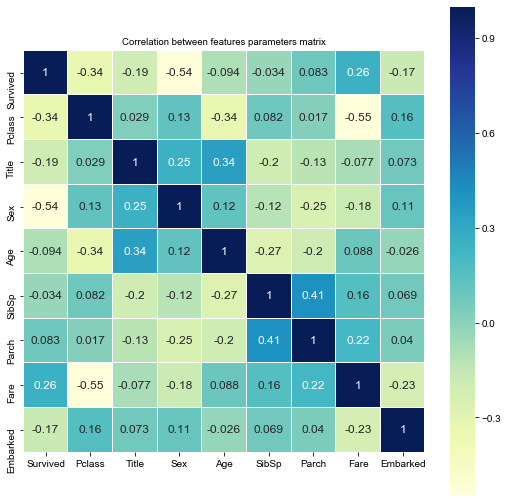

```python
view_correlation(train) ## remove srvived ******
```

#### since there is no perfect or high corelation between the features we will build the models with all of the features at the begining

# **4. Prediction Models**

### **Clustering The Data**

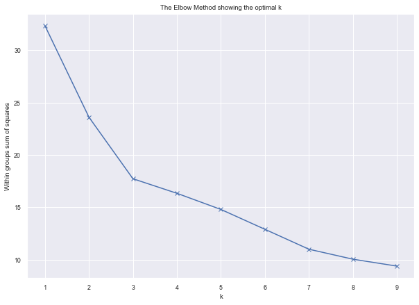

```python
elbow_met(train)
```

```python
train_with_cluster=train
```

```python
k=3
kmeans = KMeans(n_clusters = k).fit(train_with_cluster)
train_with_cluster['cluster']= kmeans.labels_ # add the clusters
```

```python
RSEED = 10
```

## **Train , Test split**

```python
feature_cols = ['Pclass','Title','Sex', 'Age','SibSp','Parch','Fare','Embarked']
x = train[feature_cols]
y = train.Survived
train_x, test_x, train_y, test_y = train_test_split(x, y, test_size=0.3, random_state=1)

# with the cluster as a feature
feature_cols = ['Pclass','Title','Sex', 'Age','SibSp','Parch','Fare','Embarked','cluster']
x = train_with_cluster[feature_cols]
y = train_with_cluster.Survived
train_x_with_cluster, test_x_with_cluster, train_y_with_cluster, test_y_with_cluster = train_test_split(x, y, test_size=0.3, random_state=1)
```

## **Random forest**

### **without clustering :**

**The base model**

```python
rfc = RandomForestClassifier(n_estimators = 300 ,random_state = RSEED ,min_samples_split = 5)
rfc = rfc.fit(train_x,train_y)
pred_y = rfc.predict(test_x)
score = accuracy_score(pred_y,test_y)
print('Accuracy : ',score)
```

```
Accuracy :  0.8352059925093633
```

**The tuned model**

```python
# Hyperparameter grid
param_grid = {
    'n_estimators': [10,100, 200, 250] ,#The number of trees in the forest.
    'max_depth':    [None, 50, 60, 70] ,#The maximum depth of the tree.
    'max_features': ['sqrt', None],#he number of features to consider when looking for the best split
    'min_samples_split': [2, 10],#The minimum number of samples required to split an internal node
    'bootstrap': [True, False]#Whether bootstrap samples are used when building trees.
}
rs = GridSearchCV(rfc, param_grid, n_jobs = -1,scoring = 'accuracy', cv = 5 ,iid=False)

rs.fit(train_x,train_y)
pred_y=rs.predict(test_x)
score = accuracy_score(pred_y,test_y)
print('Accuracy : ',score)
```

```
Accuracy :  0.850187265917603
```

**droping features**

```python
model=rs.best_estimator_
best_model_without_cl,excluded_features_without_cl = optimize_by_droping_features(train_x,train_y,test_x,test_y,3,score,model,param_grid)
```

|  | feature | importance |
| --- | --- | --- |
| 6 | Fare | 0.220919 |
| 2 | Sex | 0.219404 |
| 3 | Age | 0.176580 |
| 1 | Title | 0.150512 |
| 0 | Pclass | 0.097118 |
| 4 | SibSp | 0.053249 |
| 7 | Embarked | 0.042907 |
| 5 | Parch | 0.039312 |

```
Trying To Drop Feature : Parch
Optimizing The Best Model Without The Feature , Please Wait ⏳ ...
Accuracy After Droping Feature :  0.8689138576779026
Droping Feature Was Efficient ✔️
excluded_features ['Parch']
```

|  | feature | importance |
| --- | --- | --- |
| 2 | Sex | 0.292201 |
| 5 | Fare | 0.258310 |
| 3 | Age | 0.189801 |
| 0 | Pclass | 0.092162 |
| 1 | Title | 0.079377 |
| 4 | SibSp | 0.054084 |
| 6 | Embarked | 0.034065 |

```
Trying To Drop Feature : Embarked
Optimizing The Best Model Without The Feature , Please Wait ⏳ ...
Accuracy After Droping Feature :  0.8614232209737828
Droping Feature Was Not Efficient ❌

Optimization By Droping Features Is Done
excluded_features ['Parch']

The Best Score For Model is :  0.8689138576779026
```

### with clustering

**The base model**

```python
rfc_with_cluster = RandomForestClassifier(n_estimators = 300 ,random_state = RSEED ,min_samples_split = 5)
rfc_with_cluster = rfc_with_cluster.fit(train_x_with_cluster,train_y_with_cluster)
pred_y = rfc_with_cluster.predict(test_x_with_cluster)
score = accuracy_score(pred_y,test_y_with_cluster)
print('Accuracy : ',score)
```

```
Accuracy :  0.8352059925093633
```

**The tuned model**

```python
rs = GridSearchCV(rfc_with_cluster, param_grid, n_jobs = -1,scoring = 'accuracy', cv = 5 ,iid=False)
rs.fit(train_x_with_cluster,train_y_with_cluster)
pred_y=rs.predict(test_x_with_cluster)
score = accuracy_score(pred_y,test_y_with_cluster)
print('Accuracy : ',score)
```

```
Accuracy :  0.8539325842696629
```

**droping features**

```python
model=rs.best_estimator_
best_model_with_cl,excluded_features_with_cl=optimize_by_droping_features(train_x_with_cluster,train_y_with_cluster,
                                                                          test_x_with_cluster,test_y_with_cluster,3,
                                                                          score,model,param_grid)
```

|  | feature | importance |
| --- | --- | --- |
| 2 | Sex | 0.231983 |
| 1 | Title | 0.172789 |
| 6 | Fare | 0.167723 |
| 3 | Age | 0.167636 |
| 0 | Pclass | 0.098113 |
| 4 | SibSp | 0.056264 |
| 7 | Embarked | 0.042809 |
| 8 | cluster | 0.034657 |
| 5 | Parch | 0.028026 |

```
Trying To Drop Feature : Parch
Optimizing The Best Model Without The Feature , Please Wait ⏳ ...
Accuracy After Droping Feature :  0.846441947565543
Droping Feature Was Not Efficient ❌

Optimization By Droping Features Is Done
excluded_features []

The Best Score For Model is :  0.8539325842696629
```

### Conclusion for random forest: adding the cluster as a feature wasn't better so we will use the model without the cluster to predict the real test

#### train the model with train and validation as one set :

```python
full_train = pd.concat([train_x,test_x])  ## train + validation
full_train = full_train.drop(excluded_features_without_cl,1) ## removing feature that were excluded , if there is any
full_test  = pd.concat([train_y,test_y])
best_model_without_cl.fit(full_train,full_test) ## train the model with train + validation
```

```
RandomForestClassifier(bootstrap=True, class_weight=None, criterion='gini',
                       max_depth=None, max_features='sqrt', max_leaf_nodes=None,
                       min_impurity_decrease=0.0, min_impurity_split=None,
                       min_samples_leaf=1, min_samples_split=10,
                       min_weight_fraction_leaf=0.0, n_estimators=10,
                       n_jobs=None, oob_score=False, random_state=10, verbose=0,
                       warm_start=False)
```

#### predicting the real-life test set and exporting the result to csv :

```python
pred_y = best_model_without_cl.predict(real_life_test.drop(excluded_features_without_cl,1))
predections = pd.DataFrame({'PassengerId' : list(passengers_id),'Survived' : list(pred_y) }, columns=['PassengerId', 'Survived'])
# predections.to_csv("Random_Forest_Without_Clustering.csv", index=False)
```

## **KNN**

```python
knn = KNeighborsClassifier(n_neighbors=10, metric='euclidean')
knn.fit(train_x, train_y)
accuracy_score(knn.predict(test_x),test_y)
```

```
0.7078651685393258
```

```python
#List Hyperparameters that we want to tune.
leaf_size = list(range(1,50))
n_neighbors = list(range(1,30))
p=[1,2]
#Convert to dictionary
hyperparameters = dict(leaf_size=leaf_size, n_neighbors=n_neighbors, p=p)
#Create new KNN object
knn_2 = KNeighborsClassifier()
#Use GridSearch
clf = GridSearchCV(knn_2, hyperparameters, cv=10)
#Fit the model
best_model = clf.fit(train_x,train_y)
#Print The value of best Hyperparameters
print('Best leaf_size:', best_model.best_estimator_.get_params()['leaf_size'])
print('Best p:', best_model.best_estimator_.get_params()['p'])
print('Best n_neighbors:', best_model.best_estimator_.get_params()['n_neighbors'])
```

```
Best leaf_size: 1
Best p: 1
Best n_neighbors: 13
```

```python
score=accuracy_score(best_model.predict(test_x),test_y)
print(score)
```

```
0.7528089887640449
```

*** with clustering

```python
knn = KNeighborsClassifier(n_neighbors=10, metric='euclidean')
knn.fit(train_x_with_cluster, train_y_with_cluster)
pred_y = knn.predict(test_x_with_cluster)
accuracy_score(pred_y,test_y_with_cluster)
```

```
0.7116104868913857
```

```python
knn_2 = KNeighborsClassifier()
#Use GridSearch
clf = GridSearchCV(knn_2, hyperparameters, cv=10)
#Fit the model
best_model = clf.fit(train_x_with_cluster,train_y_with_cluster)
#Print The value of best Hyperparameters
print('Best leaf_size:', best_model.best_estimator_.get_params()['leaf_size'])
print('Best p:', best_model.best_estimator_.get_params()['p'])
print('Best n_neighbors:', best_model.best_estimator_.get_params()['n_neighbors'])
```

```
Best leaf_size: 1
Best p: 1
Best n_neighbors: 13
```

```python
score=accuracy_score(best_model.predict(test_x_with_cluster),test_y_with_cluster)
print(score)
```

```
0.7490636704119851
```

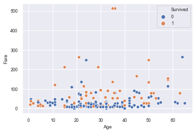

```python
sns.scatterplot(
    x='Age',
    y='Fare',
    hue='Survived',
    data=test_x.join(test_y, how='outer')
)
```

```python
from sklearn.ensemble import AdaBoostClassifier
adb = AdaBoostClassifier()
adb.fit(train_x,train_y)
pred_y = adb.predict(test_x)
score = accuracy_score(pred_y,test_y)
print(score)
```

```
0.8314606741573034
```

```python
adb = AdaBoostClassifier(n_estimators=1000,learning_rate=0.5,algorithm='SAMME.R',random_state=RSEED)
adb.fit(train_x,train_y)
pred_y = adb.predict(test_x)
score = accuracy_score(pred_y,test_y)
print(score)
```

```
0.8389513108614233
```

```python
adb_param_grid = {'n_estimators' : [10,20,50,100,200,300,400,500,1000], #Number of weak learners to train iteratively.,
                  'learning_rate': [0.001,0.01,0.03 ,0.05, 0.07,0.1,0.5, 1],
                  'algorithm'    : ['SAMME.R'],#It contributes to the weights of weak learners. It uses 1 as a default value.,
                  'random_state' : [RSEED] }

gs = GridSearchCV(adb,param_grid = adb_param_grid, cv = 5, n_jobs = -1)
best_adb = gs.fit(train_x,train_y)
pred_y = best_adb.predict(test_x)
score = accuracy_score(pred_y,test_y)
print(score)
```

```
0.8202247191011236
```

```python
best_model_with_clustering,excluded_features_with_clustering=optimize_by_droping_features(train_x,train_y,test_x,test_y,3,score,adb,adb_param_grid)
```

|  | feature | importance |
| --- | --- | --- |
| 6 | Fare | 0.38 |
| 3 | Age | 0.30 |
| 1 | Title | 0.12 |
| 4 | SibSp | 0.08 |
| 2 | Sex | 0.04 |
| 7 | Embarked | 0.04 |
| 0 | Pclass | 0.02 |
| 5 | Parch | 0.02 |

[output not shown]

```python
!jupyter nbconvert --to html Titanic.ipynb
```

```
[NbConvertApp] Converting notebook Titanic.ipynb to html
[NbConvertApp] Writing 488454 bytes to Titanic.html
```